# RSF simulations

Marie Auger-Méthé

2025-11-12

# Goals

1. Use simulations to show that ignoring health and/or fitness proxies can bias selection analysis.
2. Check that proposed methodology works.
3. Additional small technical check: confirm that we need a random effect on intercept when there is only 1 location per individual (as in the murre example).

# General set up

## Load packages

```r
library(terra) # for transforming rasters into terra objects for plotting
library(tidyterra) # for easy plotting of rasters
library(sf)
library(fields) # to simulate data with prioritizr
library(prioritizr) # to simulate Gaussian random fields
library(tidyverse)
library(ggpubr)
library(amt) # to fit ssf
#install.packages("glmmTMB", type="source") # If problems with TMB version
library(glmmTMB) # to fit rsf
library(MuMIn) # for AICc
```

## Plot set up

```r
# Colour for proxy
proxy.min.col <- "#d73027"
proxy.mid.col <- "#ffffbf"
proxy.max.col <- "#4575b4"
# Size of title/labels
axis.title.size <- rel(1)
axis.label.size <- rel(0.8)
```

# General simulation set up - with simple example

## Simulate spatial covariates

Simulate a spatial covariate using a Gaussian random field.

First, we will define the size of our study area and create a base raster.

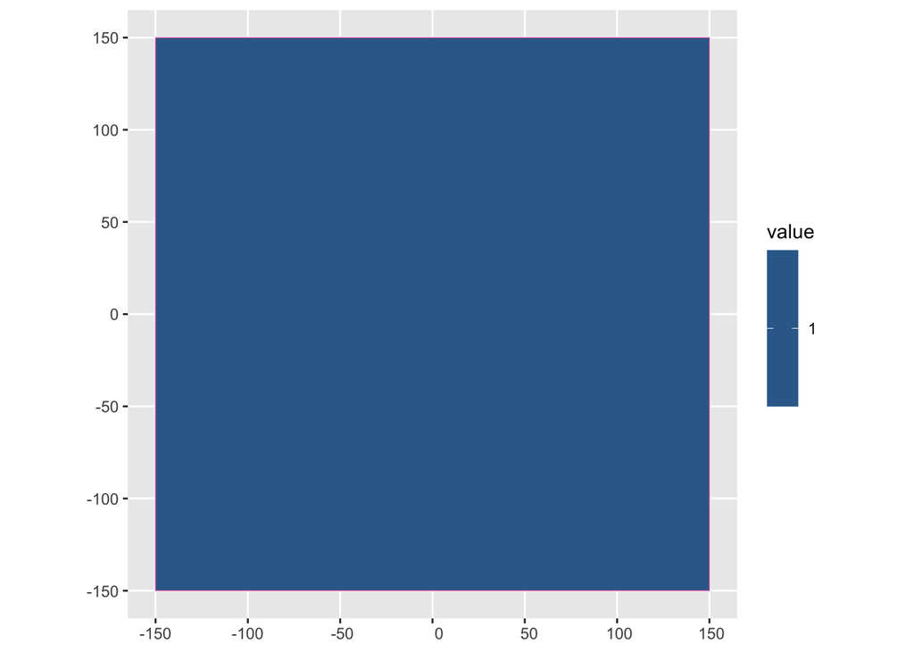

```r
study.area <- terra::rast(
  ncols = 100, nrows = 100, xmin = -150, xmax = 150, ymin = -150, ymax = 150, vals = 1
)

# Create a polygon of study area for sampling
study.area.sf <- st_as_sf(as.polygons(study.area))

ggplot() +
  geom_spatraster(data = study.area) +
  geom_sf(data = study.area.sf, fill=NA, col="hotpink")
```

Then, we use the function `simulate_data` from the packages `prioritizr`. The argument `scale` defines the spatial autocorrelation, while the `sd` the standard deviation of the data, and `n` is the number of layers. Here, we simulate one covariate named `cov1`.

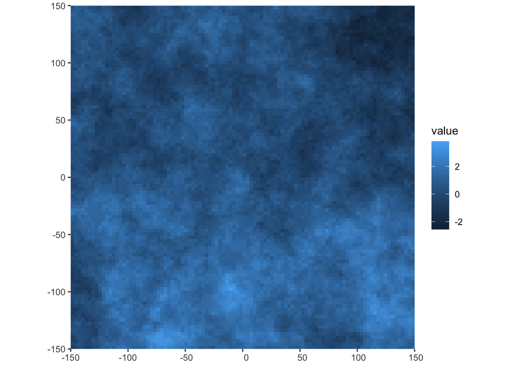

```r
set.seed(1987)

# Simulate data using a Gaussian field
cov1 <- simulate_data(study.area, n = 1, scale = 0.9, sd = 0.1)
# Plot spatial covariate
ggplot() + geom_spatraster(data = cov1) + coord_sf(expand = FALSE)
```

## Function to sample locations based on Resource Selection Function (RSF)

Create a function that selects `n.points` number of points. We assume that the whole study area is available and that the selection is proportional to $\text{exp}((\beta_1 + \beta_2 h_n)x_i)$, where $h_n$ is the health/fitness proxy value for individual $n$.

```r
sim.rsf <- function(n, n.points, proxy, cov, betas){
  used <- NULL
  for(i in 1:n){
    rsf <- exp(betas[1]*cov[[1]] + proxy[i]*betas[2]*cov[[1]])
    used.i <- sf::st_as_sf(spatSample(x = rsf, size = n.points,
                                      method = "weights", replace=TRUE, as.points=TRUE))
    used.i$ID <- i
    used.i$proxy <- proxy[i]
    used <- rbind(used, used.i)
  }

  return(used)
}
```

Test the simulation function.

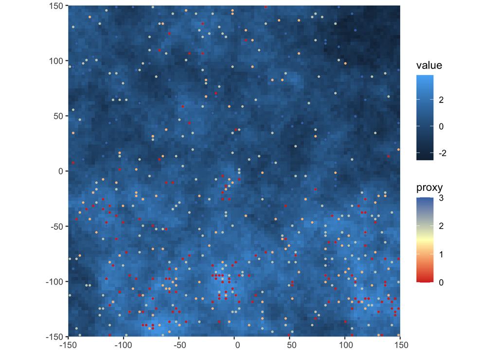

```r
n <- 20 # Number of individuals
n.points <- 30 # Number of points per individual
cov <- cov1
betas.test <- c(1.5, -0.5)
val.proxy <- 0:3

set.seed(277711)
# Sample proxy value for each individual
proxy <- sample(val.proxy, size=n, replace = TRUE)

# Sample points
sim.test <- sim.rsf(n, n.points, proxy, cov, betas.test)

ggplot() + geom_spatraster(data = cov1) +
      geom_sf(data=sim.test, aes(col = proxy), size=0.5) +
      scale_color_gradient2(low=proxy.min.col,
                            mid=proxy.mid.col, high= proxy.max.col,
                            midpoint = mean(val.proxy), limit = range(val.proxy),
                            na.value = NA) +
      coord_sf(expand = FALSE)
```

## Function to fit RSF

We have two functions, one that samples available points using package `amt` and one that fits the RSF model using the package `glmmTMB`.

```r
# Sample available points
avail.rsf <- function(n.avail, study.area.sf, used.sf, cov){
  # Sample random points
  rsf.avail <- random_points(study.area.sf, n=nrow(used.sf)*n.avail)
  rsf.avail.sf <- st_as_sf(as.data.frame(rsf.avail), coords=c("x_", "y_"), remove = FALSE)

  # Merge with used
  cols <- c("ID", "proxy")
  used.sf$case_ <- TRUE
  used.df <- st_drop_geometry(used.sf)

  for(i in seq_along(cols)){
    rsf.avail.sf[, cols[i]] <- rep(used.df[,cols[i]], each = n.avail)
  }

  rsf.all.sf <- rbind(used.sf[, c("case_", cols)],
                      rsf.avail.sf[, c("case_", cols)])

  # Extract covariates
  rsf.all.sf$cov <- unlist(terra::extract(cov, rsf.all.sf, ID=FALSE))

  all.steps <- as.data.frame(rsf.all.sf)

  # As numeric
  all.steps$case <- as.numeric(all.steps$case_)

  return(all.steps)
}
```

Muff et al. (2020) uses a standard deviation of 1000 for the random effect of the intercept, but here doing so created convergence problems and as such we use a larger standard deviation value of 10000.

```r
fit.rsf <- function(all.steps, formula.rsf,
                    start = list(theta = c(log(10000), 0, 0)),
                    map = list(theta = factor(c(NA, 1, NA)))){


  # Weight for rsf. See Muff et al. 2020
  all.steps$weight <- 1000^(1-all.steps$case)
  # Fit rsf model
  model.rsf <- glmmTMB(formula.rsf, family=binomial,
                     data = all.steps,
                     start = start , map = map,
                     weights = weight)
  return(model.rsf)
}
```

Test the function.

```r
# Number of available per locations
n.avail <- 30
set.seed(87876982)
all.test <- avail.rsf(n.avail, study.area.sf, used.sf = sim.test, cov = cov1)
m.test <- fit.rsf(all.test,
                  formula.rsf = case ~
                    cov +
                    proxy:cov +
                    (1 + cov | ID))
summary(m.test)
```

```
##  Family: binomial  ( logit )
## Formula:          case ~ cov + proxy:cov + (1 + cov | ID)
## Data: all.steps
## Weights: weight
##
##       AIC       BIC    logLik -2*log(L)  df.resid
##   13617.1   13648.4   -6804.6   13609.1     18596
##
## Random effects:
##
## Conditional model:
##  Groups Name        Variance  Std.Dev.  Corr
##  ID     (Intercept) 1.000e+08 1.000e+04
##         cov         8.253e-03 9.085e-02 0.00
## Number of obs: 18600, groups:  ID, 20
##
## Conditional model:
##               Estimate Std. Error z value Pr(>|z|)
## (Intercept) -2.164e-05  2.237e+03    0.00        1
## cov          1.444e+00  8.718e-02   16.57   <2e-16 ***
## cov:proxy   -4.954e-01  4.566e-02  -10.85   <2e-16 ***
## ---
## Signif. codes:  0 '***' 0.001 '**' 0.01 '*' 0.05 '.' 0.1 ' ' 1
```

```r
cbind(summary(m.test)$coefficient$cond[c("cov", "cov:proxy"),], betas.test)
```

```
##            Estimate Std. Error   z value     Pr(>|z|) betas.test
## cov        1.444383 0.08718329  16.56720 1.203014e-61        1.5
## cov:proxy -0.495410 0.04565869 -10.85029 1.987977e-27       -0.5
```

Estimates are close to the simulated values.

# Simulations

Basic set up for all simulations, except if otherwise stated.

```r
# Number of individuals
n <- 30
# Number of points per individual
n.points <- 50
# Number of simulations per scenario
n.sim <- 100
# Number of available points per used points
n.avail <- 100
```

## Baseline check: verify that we can recover what we should when health/fitness proxie does not alter selection

Here, we verify that the baseline model, which does not include the interaction with the health/fitness proxy, returns unbiased results when there are no difference between individuals. We are primarily verifying that the biases found in the scenarios presented in the main text are linked to the individual differences in health/fitness, not a problem with the baseline model. We are also verifying whether the AICc would select the appropriate model.

We simulate location data based on RSF without any health or fitness proxy, and make sure we recover parameter estimates.

**This will take mins to hours to run on most computers.** We provided a .csv file with the results in the repository that can be loaded below.

```r
t0 <- Sys.time()
betas <- c(0.5, 0) # Here the beta associated with the proxy is 0 (no effect)
val.proxy <- rep(c(-1,0,1), each = n/3) # balance ratio. Irrelevant since beta_2 = 0


sim.res.sc1 <- as.data.frame(matrix(nrow = n.sim, ncol = 10))
colnames(sim.res.sc1) <- c("sim", "beta_cov_sim", "beta_cov_est", "beta_cov_SE",
                           "beta_cov_95LCI", "beta_cov_95UCI", "beta_cov_in_95CI",
                           "converg.mess", "AICc_baseline", "AICc_new")

set.seed(12345)
for(s in 1:n.sim){
  sim.res.sc1[s, "sim"] <- s
  sim.res.sc1[s, "beta_cov_sim"] <- betas[1]
  cov.s <- simulate_data(study.area, n = 1, scale = 0.9, sd = 0.1)
  sim.s <- sim.rsf(n, n.points, val.proxy, cov.s, betas)
  all.s <- avail.rsf(n.avail, study.area.sf, used.sf = sim.s, cov = cov.s)
  # Fit baseline
  fit.s <- fit.rsf(all.s,
                   formula.rsf = case ~ cov + (1 + cov | ID))
  sim.res.sc1[s, c("beta_cov_est", "beta_cov_SE")] <- summary(fit.s)$coefficient$cond["cov", c("Estimate", "Std. Error")]
  sim.res.sc1[s, c("beta_cov_95LCI", "beta_cov_95UCI")] <- confint(fit.s, "cov")[,1:2]
  sim.res.sc1[s, "converg.mess"] <- fit.s$fit$convergence # 0 means that the model converged
  sim.res.sc1[s, "AICc_baseline"] <- AICc(fit.s)
  # Fit new model (wrong model here)
  fit.s.n <- fit.rsf(all.s,
                   formula.rsf = case ~ cov + cov:proxy + (1 + cov | ID))
  sim.res.sc1[s, "AICc_new"] <- AICc(fit.s.n)
}

Sys.time() - t0
```

```
## Time difference of 35.18073 mins
```

```r
sim.res.sc1$beta_cov_in_95CI <- sim.res.sc1$beta_cov_95LCI <= sim.res.sc1$beta_cov_sim &
  sim.res.sc1$beta_cov_sim <= sim.res.sc1$beta_cov_95UCI

# Look at AICc difference,  new model (wrong model, more complex) - baseline model (good model)
sim.res.sc1$deltaAICc <- sim.res.sc1$AICc_new - sim.res.sc1$AICc_baseline


# Save file
write.csv(sim.res.sc1,
          file = paste("sim.rsf.sc1_", format(Sys.time(), "%Y%m%d"), ".csv",
                               sep=""),
          row.names = FALSE)
```

There are some warning messages (not shown in compiled version). Let’s check whether the models converged.

To load the file we have created, uncomment the first line.

```r
# sim.res.sc1 <- read.csv("sim.rsf.sc1_20251112.csv")
# How many simulations did not converge properly.
sum(sim.res.sc1$converg.mess != 0)
```

```
## [1] 0
```

None of the simulations have a convergence message.

Let’s have a quick look at the results.

```r
head(sim.res.sc1)
```

```
##   sim beta_cov_sim beta_cov_est beta_cov_SE beta_cov_95LCI beta_cov_95UCI
## 1   1          0.5    0.5330166  0.03591880      0.4626170      0.6034161
## 2   2          0.5    0.4702257  0.03194374      0.4076171      0.5328343
## 3   3          0.5    0.4771719  0.02703530      0.4241837      0.5301601
## 4   4          0.5    0.5003069  0.02612336      0.4491061      0.5515077
## 5   5          0.5    0.5165036  0.02983009      0.4580377      0.5749695
## 6   6          0.5    0.4947159  0.02994453      0.4360257      0.5534061
##   beta_cov_in_95CI converg.mess AICc_baseline AICc_new deltaAICc
## 1             TRUE            0      37877.37 37879.26  1.889402
## 2             TRUE            0      37994.94 37996.07  1.135052
## 3             TRUE            0      37907.49 37908.73  1.245089
## 4             TRUE            0      37842.19 37844.14  1.944764
## 5             TRUE            0      37829.44 37831.38  1.937847
## 6             TRUE            0      37928.10 37929.93  1.826493
```

At first glance, the results look good.

Let’s look at our parameter estimates in more details.

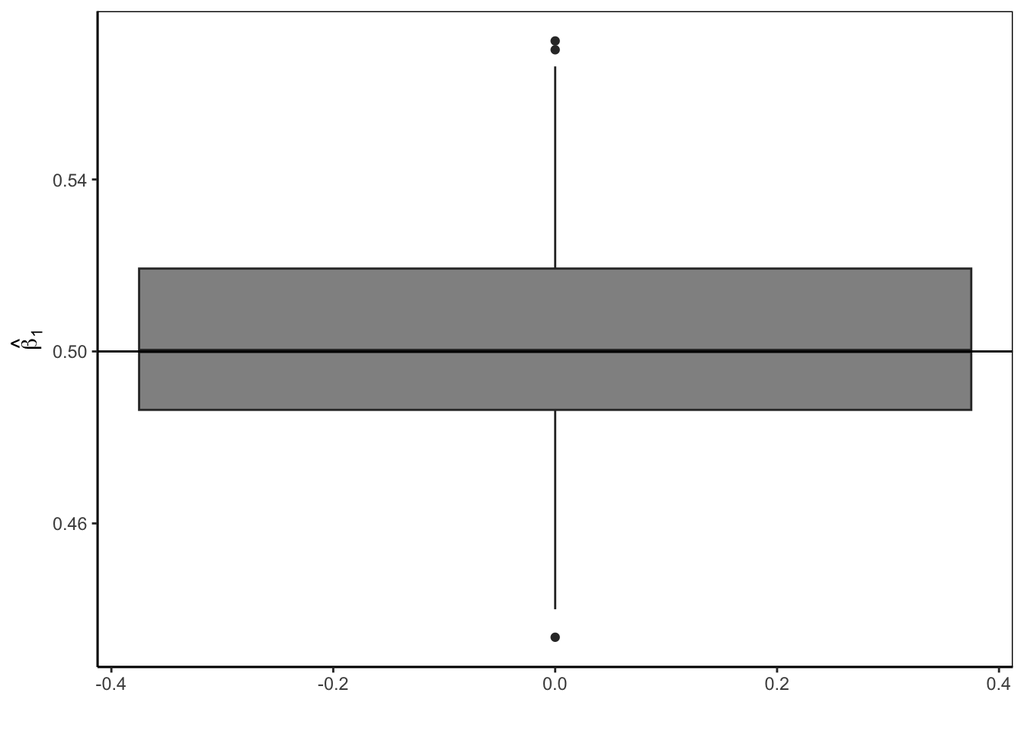

```r
plot.1 <- ggplot() +
  geom_boxplot(data = sim.res.sc1, aes(y = beta_cov_est),
               fill = alpha("black", 0.5)) +
  geom_hline(aes(yintercept = betas[1])) +
  xlab("") + ylab(expression(hat(beta)[1])) +
  theme_classic() +
  theme(panel.border = element_rect(fill=NA, linewidth = 0.5))

plot.1
```

The parameter estimates are close to the true value.

Let’s further explore coverage.

```r
# Coverage - should be ~ 95%
sum(sim.res.sc1$beta_cov_in_95CI)/n.sim
```

```
## [1] 0.96
```

Verify that AICc would select the good model. Here the baseline model should have the lowest AICc, and thus the difference should be positive. Look at histogram.

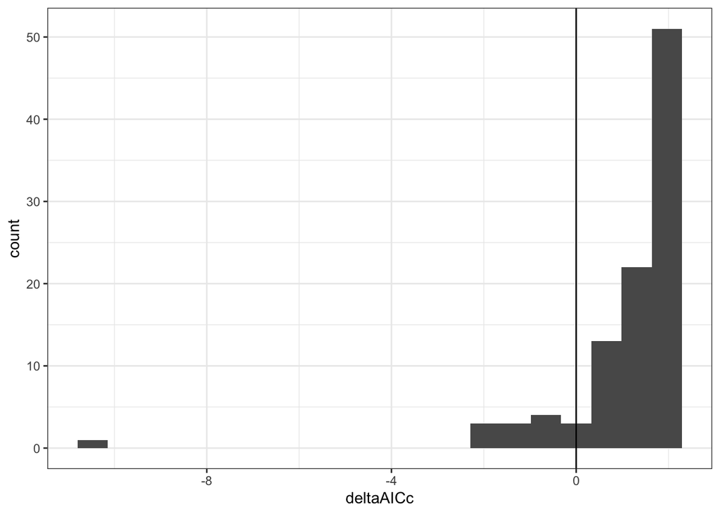

```r
ggplot(data = sim.res.sc1) +
  geom_histogram(aes(x = deltaAICc), bins = 20) +
  theme_bw() +
  geom_vline(xintercept = 0)
```

How many are negative?

```r
sim.res.sc1 %>% filter(deltaAICc < 0) %>% nrow()
```

```
## [1] 12
```

Thus, AICc would choose the wrong model 12% of the time.

Let’s see the results if we only select the new model if the difference is greater than 2 (i.e., 2 times the number of parameter difference).

```r
sim.res.sc1 %>% filter(deltaAICc < -2) %>% nrow()
```

```
## [1] 2
```

With this more conservative method, AICc would choose the wrong model only 2% of the time (i.e. type I error rate is 2%). This may change with sample size.

## Main scenarios: see what happens when individual differ, but the proxy is not included vs included

Here, we will create simulations where an individual’s health/fitness proxy value affects the selection. We will use these simulations to demonstrate that ignoring health/fitness proxies can bias our results.

We will look at two scenarios, which are the two RSF scenarios presented in the main text:

**Scenario A** (sometimes referred as `sc2.a` in the code): There is a general trend towards selecting higher values of the environmental covariate, but those with higher health/fitness proxy value do so more strongly, and those with lower health/fitness proxy value (i.e., -1, see below) avoid areas with higher values of this environmental covariate. This scenario could represent lower health/fitness individuals being out-competed by individuals in better conditions, and have to go to lower quality habitat. In this case $\beta_1 = 0.5$ and $\beta_2 = 1$.

**Scenario B** (sometimes referred as `sc2.b` in the code): Individuals do not generally select for higher or lower values of the covariate, but individuals with higher fitness specifically avoid higher values while those of lower fitness do select theses areas. In this case $\beta_1 = 0$ and $\beta_2 = -1$.

For all scenarios, the proxy values can be either -1 (less healthy/fit than average), 0 (average individual), and 1 (more healthy/fit than average). We have sub-scenarios where we modify the ratio of individuals with each proxy values: i) 3:2:1 (more individual with proxy value of -1), ii) 1:1:1 (balanced), and iii) 1:2:3 (more individual with proxy value of 1).

This code chunk defines the simulation settings.

```r
# Two scenarios
betas.sc2 <- matrix(c(0.5, 1, # Scenario A
                      0, -1), # Scenario B
                    nrow=2, byrow=TRUE)

# Sub-scenarios
# This work with n = 30
proxy.sc2 <- rbind(c(n/6*3, n/6*2, n/6), # i
                   c(n/6*2, n/6*2, n/6*2), # ii
                   c(n/6*1, n/6*2, n/6*3)) # iii
colnames(proxy.sc2) <- c("n_m1", "n_0", "n_p1")

# Table for results
sim.res.sc2 <- as.data.frame(matrix(nrow = n.sim*nrow(proxy.sc2)*2, ncol = 26))
colnames(sim.res.sc2) <- c("sim", "n_m1", "n_0", "n_p1", "cov.sim.index",
                           "beta_cov_sim", "beta_cov_proxy_sim",
                           "beta_cov_est", "beta_cov_SE",
                           "beta_cov_95LCI", "beta_cov_95UCI",
                           "beta_cov_in_95CI",
                           "beta_cov_est_new", "beta_cov_SE_new",
                           "beta_cov_95LCI_new", "beta_cov_95UCI_new",
                           "beta_cov_in_95CI_new",
                           "beta_cov_proxy_est_new", "beta_cov_proxy_SE_new",
                           "beta_cov_proxy_95LCI_new", "beta_cov_proxy_95UCI_new",
                           "beta_cov_proxy_in_95CI_new",
                           "converg_mess_baseline", "converg_mess_new",
                           "AICc_baseline", "AICc_new")

# Simulation ID
sim.res.sc2[,"sim"] <- 1:(n.sim*nrow(betas.sc2)*nrow(proxy.sc2))

# Index of covariate used
sim.res.sc2[,"cov.sim.index"] <- rep(1:n.sim, nrow(betas.sc2)*nrow(proxy.sc2))

# Number of individuals (sub-scenarios)
sim.res.sc2[, "n_m1"] <- rep(proxy.sc2[,"n_m1"], each = n.sim*nrow(betas.sc2))
sim.res.sc2[, "n_0"] <- rep(proxy.sc2[,"n_0"], each = n.sim*nrow(betas.sc2))
sim.res.sc2[, "n_p1"] <- rep(proxy.sc2[,"n_p1"], each = n.sim*nrow(betas.sc2))

# Betas (scenarios)
sim.res.sc2[, "beta_cov_sim"] <- rep(betas.sc2[,1], each = n.sim)
sim.res.sc2[, "beta_cov_proxy_sim"] <- rep(betas.sc2[,2], each = n.sim)

# As factor
sim.res.sc2$beta_sim_factor <- paste(sim.res.sc2$beta_cov_sim, sim.res.sc2$beta_cov_proxy_sim)
sim.res.sc2$proxy_factor <- factor(paste("-1: ", sim.res.sc2$n_m1,
                                         ", 0: ", sim.res.sc2$n_0,
                                         ", +1: ", sim.res.sc2$n_p1, sep = ""),
                                      levels = c("-1: 5, 0: 10, +1: 15",
                                                 "-1: 10, 0: 10, +1: 10",
                                                 "-1: 15, 0: 10, +1: 5"))
```

This code chunk simulates the covariate rasters.

```r
# Use same covariate layer for each scenario
set.seed(123454321)
cov.sc2 <- simulate_data(study.area, n = 1, scale = 0.9, sd = 0.1)


for(i in 2:n.sim){
  cov.sc2 <- rast(list(cov.sc2,
                       simulate_data(study.area, n = 1, scale = 0.9, sd = 0.1)))
}
```

This code chunk runs the simulations for both scenarios.

**This will take mins to hours to run on most computers.** We provided a .csv file with the results in the repository that can be loaded below.

```r
t0 <- Sys.time()
set.seed(666555444)

for(s in 1:nrow(sim.res.sc2)){
  sim.s <- sim.rsf(n, n.points,
                   proxy = c(rep(-1, sim.res.sc2[s, "n_m1"]),
                             rep(0, sim.res.sc2[s, "n_0"]),
                             rep(+1, sim.res.sc2[s, "n_p1"])),
                   cov.sc2[[sim.res.sc2[s,"cov.sim.index"]]],
                   betas = as.numeric(sim.res.sc2[s, c("beta_cov_sim",
                                                       "beta_cov_proxy_sim")]))
  all.s <- avail.rsf(n.avail, study.area.sf, used.sf = sim.s,
                     cov = cov.sc2[[sim.res.sc2[s,"cov.sim.index"]]])

  # Baseline model
  fit.s.no.proxy <- fit.rsf(all.s,
                            formula.rsf = case ~ cov +
                              (1 + cov | ID))
  sim.res.sc2[s, c("beta_cov_est", "beta_cov_SE")] <-
    summary(fit.s.no.proxy)$coefficient$cond["cov", c("Estimate", "Std. Error")]
  sim.res.sc2[s, c("beta_cov_95LCI", "beta_cov_95UCI")] <-
    confint(fit.s.no.proxy, "cov")[,1:2]
  sim.res.sc2[s, "converg_mess_baseline"] <-
    fit.s.no.proxy$fit$convergence
  sim.res.sc2[s, "AICc_baseline"] <- AICc(fit.s.no.proxy)

  # New model with proxy
   fit.s.proxy <- fit.rsf(all.s,
                         formula.rsf = case ~ cov + cov:proxy +
                           (1 + cov | ID))
  sim.res.sc2[s, c("beta_cov_est_new", "beta_cov_SE_new")] <-
    summary(fit.s.proxy)$coefficient$cond["cov", c("Estimate", "Std. Error")]
  sim.res.sc2[s, c("beta_cov_95LCI_new", "beta_cov_95UCI_new")] <-
    confint(fit.s.proxy, "cov")[,1:2]
  sim.res.sc2[s, c("beta_cov_proxy_est_new", "beta_cov_proxy_SE_new")] <-
    summary(fit.s.proxy)$coefficient$cond["cov:proxy", c("Estimate", "Std. Error")]
  sim.res.sc2[s, c("beta_cov_proxy_95LCI_new", "beta_cov_proxy_95UCI_new")] <-
    confint(fit.s.proxy, "cov:proxy")[,1:2]
  sim.res.sc2[s, "converg_mess_new"] <-
    fit.s.proxy$fit$convergence
  sim.res.sc2[s, "AICc_new"] <- AICc(fit.s.proxy)

}
Sys.time() - t0 # 6 to 10  minutes for 2 simulations
```

```
## Time difference of 3.343162 hours
```

```r
# Look at AICc difference,  here  baseline model (wrong model, too simple) - new model (good model)
sim.res.sc2$deltaAICc <- sim.res.sc2$AICc_baseline - sim.res.sc2$AICc_new


# Save file
write.csv(sim.res.sc2,
          file = paste("sim.rsf.sc2_", format(Sys.time(), "%Y%m%d"), ".csv",
                               sep=""),
          row.names = FALSE)
```

To lead the saved results, uncomment the lines in this code chunk.

```r
# sim.res.sc2 <- read.csv("sim.rsf.sc2_20251112.csv")
# sim.res.sc2$proxy_factor <- factor(sim.res.sc2$proxy_factor,
#                                       levels = c("-1: 15, 0: 10, +1: 5",
#                                                  "-1: 10, 0: 10, +1: 10",
#                                                  "-1: 5, 0: 10, +1: 15"))
```

```r
sim.res.sc2$proxy_sf <-  factor(paste(sim.res.sc2$n_m1,
                                      sim.res.sc2$n_0,
                                      sim.res.sc2$n_p1, sep = ":"),
                                      levels = c("15:10:5",
                                                 "10:10:10",
                                                 "5:10:15"))
```

There are many warnings (not shown in compiled version). Check convergence messages and if there are any problem with estimating the SE

```r
# How many have convergence problems - baseline
sum(sim.res.sc2[,"converg_mess_baseline"] != 0)
```

```
## [1] 0
```

```r
sim.res.sc2 %>% filter(is.na(beta_cov_SE))
```

```
##  [1] sim                        n_m1
##  [3] n_0                        n_p1
##  [5] cov.sim.index              beta_cov_sim
##  [7] beta_cov_proxy_sim         beta_cov_est
##  [9] beta_cov_SE                beta_cov_95LCI
## [11] beta_cov_95UCI             beta_cov_in_95CI
## [13] beta_cov_est_new           beta_cov_SE_new
## [15] beta_cov_95LCI_new         beta_cov_95UCI_new
## [17] beta_cov_in_95CI_new       beta_cov_proxy_est_new
## [19] beta_cov_proxy_SE_new      beta_cov_proxy_95LCI_new
## [21] beta_cov_proxy_95UCI_new   beta_cov_proxy_in_95CI_new
## [23] converg_mess_baseline      converg_mess_new
## [25] AICc_baseline              AICc_new
## [27] beta_sim_factor            proxy_factor
## [29] deltaAICc                  proxy_sf
## <0 rows> (or 0-length row.names)
```

There are no convergence message and none of the simulations run returned a the standard error is `NA` when fitting the baseline model.

```r
# How many have convergence problems - new
sum(sim.res.sc2[,"converg_mess_new"] != 0)
```

```
## [1] 0
```

```r
sim.res.sc2 %>% filter(is.na(beta_cov_SE_new) | is.na(beta_cov_proxy_SE_new))
```

```
##  [1] sim                        n_m1
##  [3] n_0                        n_p1
##  [5] cov.sim.index              beta_cov_sim
##  [7] beta_cov_proxy_sim         beta_cov_est
##  [9] beta_cov_SE                beta_cov_95LCI
## [11] beta_cov_95UCI             beta_cov_in_95CI
## [13] beta_cov_est_new           beta_cov_SE_new
## [15] beta_cov_95LCI_new         beta_cov_95UCI_new
## [17] beta_cov_in_95CI_new       beta_cov_proxy_est_new
## [19] beta_cov_proxy_SE_new      beta_cov_proxy_95LCI_new
## [21] beta_cov_proxy_95UCI_new   beta_cov_proxy_in_95CI_new
## [23] converg_mess_baseline      converg_mess_new
## [25] AICc_baseline              AICc_new
## [27] beta_sim_factor            proxy_factor
## [29] deltaAICc                  proxy_sf
## <0 rows> (or 0-length row.names)
```

There are no convergence message and none of the simulation runs returned a the standard error is `NA` when fitting the new model.

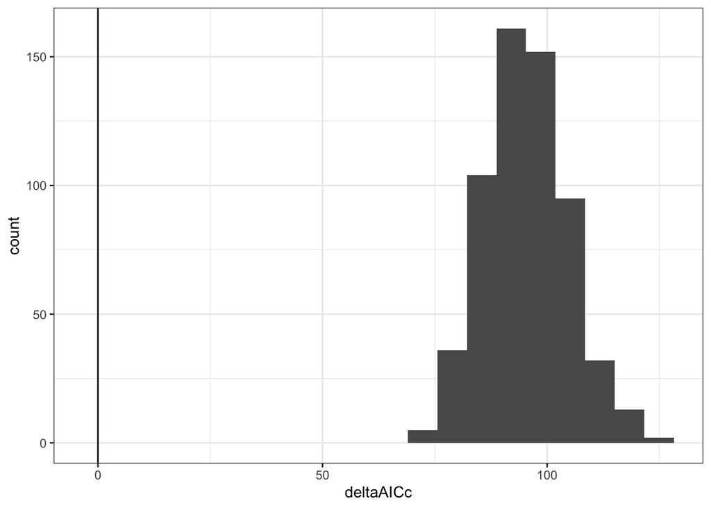

```r
ggplot(data = sim.res.sc2) +
  geom_histogram(aes(x = deltaAICc), bins = 20) +
  theme_bw() +
  geom_vline(xintercept = 0)
```

Let’s confirm that none are negative.

```r
sim.res.sc2 %>% filter(deltaAICc < 0) %>% nrow()
```

```
## [1] 0
```

Thus, AICc would choose the wrong model 0% of the time.

If we only select the new model if the difference is greater than 2 (i.e. 2 times the number of parameter difference, here 1).

```r
sim.res.sc2 %>% filter(deltaAICc < -2) %>% nrow()
```

```
## [1] 0
```

Thus, AICc would choose the wrong model only 0% of the time. If we assume that the null model is the baseline model, type II error rate is 0% (i.e, power of 100%). The power will change with sample size, etc.

Check if estimate is in 95 CI, so that we can calculate coverage.

```r
# Base line model
sim.res.sc2$beta_cov_in_95CI <- sim.res.sc2$beta_cov_95LCI <= sim.res.sc2$beta_cov_sim &
  sim.res.sc2$beta_cov_sim <= sim.res.sc2$beta_cov_95UCI

# Model with proxy - general selection
sim.res.sc2$beta_cov_in_95CI_new <- sim.res.sc2$beta_cov_95LCI_new <= sim.res.sc2$beta_cov_sim &
  sim.res.sc2$beta_cov_sim <= sim.res.sc2$beta_cov_95UCI_new

# Model with proxy - relationship with proxy
sim.res.sc2$beta_cov_proxy_in_95CI_new <- sim.res.sc2$beta_cov_proxy_95LCI_new <= sim.res.sc2$beta_cov_proxy_sim &
  sim.res.sc2$beta_cov_proxy_sim <= sim.res.sc2$beta_cov_proxy_95UCI_new
```

In case some random seeds returned NA for SE, we remove those simulations before calculating coverage.

```r
# Baseline model
sum(sim.res.sc2$beta_cov_in_95CI, na.rm = TRUE)/(nrow(sim.res.sc2) - sum(is.na(sim.res.sc2[,"beta_cov_SE"])))
```

```
## [1] 0.35
```

```r
# Model with proxy - general selection
sum(sim.res.sc2$beta_cov_in_95CI_new, na.rm = TRUE)/(nrow(sim.res.sc2) - sum(is.na(sim.res.sc2[,"beta_cov_SE_new"])))
```

```
## [1] 0.9566667
```

```r
# Model with proxy - relationship with proxy
sum(sim.res.sc2$beta_cov_proxy_in_95CI_new, na.rm = TRUE)/(nrow(sim.res.sc2) - sum(is.na(sim.res.sc2[,"beta_cov_proxy_SE_new"])))
```

```
## [1] 0.9483333
```

As expected when we ignore the relationship with the proxy, the true underlying relationship is not captured, but if we fit the good model we get a coverage of about 95%.

In scenario A, which has a baseline selection of the covariate of 0.5 and 1:1 relationship with the health/fitness proxy, the environmental covariate is important for animal, especially for those that are with good “health”. Let’s see how often the baseline model, which does not include the relationship with the health/fitness proxy, would conclude that this environmental covariate is not important. To do so, we will calculate how many confidence intervals (CIs) for the coefficient from the baseline model overlap with 0.

```r
res.sc2.a <- subset(sim.res.sc2, beta_cov_sim == 0.5 & beta_cov_proxy_sim == 1)
res.sc2.a$zero_in_CI <- res.sc2.a$beta_cov_95LCI <= 0 & res.sc2.a$beta_cov_95UCI >= 0

res.sc2.a %>% group_by(proxy_factor)  %>% summarise(n = sum(zero_in_CI, na.rm = TRUE))
```

```
## # A tibble: 3 × 2
##   proxy_factor              n
##   <fct>                 <int>
## 1 -1: 5, 0: 10, +1: 15      0
## 2 -1: 10, 0: 10, +1: 10     0
## 3 -1: 15, 0: 10, +1: 5    100
```

Scenario B has a baseline selection of the covariate of 0 and a negative relationship with the health/fitness proxy, meaning that in general the animal does not select for the environmental covariate and that healthy animals avoid it. Here only individual in poor condition select it. To see whether ignoring the health/fitness proxy could mislead us to think that this environmental covariate is important for the health of animal, we look at how many CIs are fully above zero (saying that the animals select the covariate).

```r
res.sc2.b <- subset(sim.res.sc2, beta_cov_sim == 0 & beta_cov_proxy_sim == -1)
res.sc2.b$positive_CI <- res.sc2.b$beta_cov_95LCI > 0 & res.sc2.b$beta_cov_95UCI > 0

res.sc2.b %>% group_by(proxy_factor)  %>% summarise(n = sum(positive_CI, na.rm=TRUE))
```

```
## # A tibble: 3 × 2
##   proxy_factor              n
##   <fct>                 <int>
## 1 -1: 5, 0: 10, +1: 15      0
## 2 -1: 10, 0: 10, +1: 10     0
## 3 -1: 15, 0: 10, +1: 5     97
```

We remove any NA if they are present. Here 97% of the simulations with more individuals in poor fitness would show selection of this covariate (which is avoided by the healthy animals!).

Let’s look at coefficient estimates.

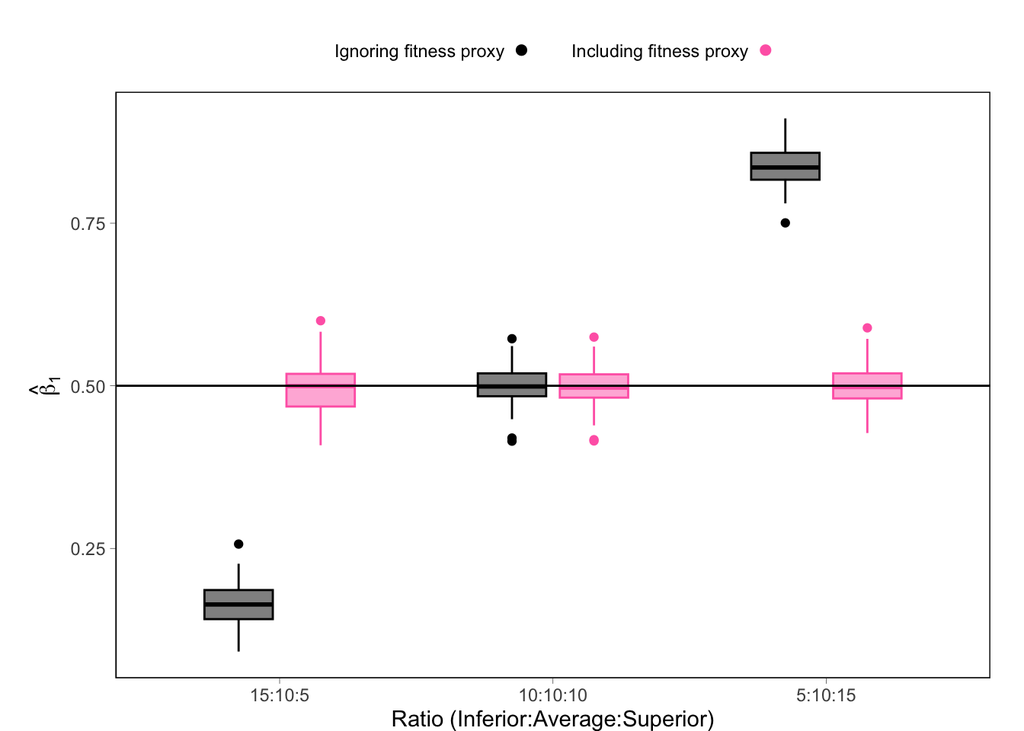

```r
col.base.method <- "black"
col.new.method <- "hotpink"

plot.sim.boxplot <- function(sim.res, beta_scenario,
                             x.title = "Ratio (Inferior:Average:Superior)"){
  subset.sc <- subset(sim.res, beta_sim_factor == beta_scenario)
  beta.sc <- unique(subset.sc$beta_cov_sim)
  p <- ggplot() +
    geom_boxplot(data = subset.sc, aes(x = proxy_sf, y= beta_cov_est),
                 width = 0.25, position= position_nudge(x = -.15),
                 col = col.base.method, fill = alpha(col.base.method, 0.5)) +
    geom_boxplot(data = subset.sc, aes(x = proxy_sf, y= beta_cov_est_new),
                 width = 0.25, position= position_nudge(x = +.15),
                 col = col.new.method, fill = alpha(col.new.method, 0.5)) +
    geom_hline(aes(yintercept = beta.sc)) +
    xlab(x.title) + ylab(expression(hat(beta)[1])) +
    theme(panel.border = element_rect(fill=NA, linewidth = 0.5)) +
    guides(Without.proxy = guide_custom(grid::circleGrob(r = unit(0.1, "cm"),
                                                  gp = grid::gpar(fill = col.base.method,
                                                                  col = NA)),
                                 title = "Ignoring fitness proxy", order = 1,
                                 theme = theme(legend.title =
                                                 element_text(size = axis.label.size),
                                               legend.position = "top")),
           With.proxy = guide_custom(grid::circleGrob(r = unit(0.1, "cm"),
                                                  gp = grid::gpar(fill =
                                                                    col.new.method,
                                                                  col = NA)),
                                 title = "Including fitness proxy", order = 2,
                                 theme = theme(legend.title =
                                                 element_text(size = axis.label.size),
                                               legend.position = "top"))) +
        theme_classic() +
    theme(legend.position = "top",
          axis.title = element_text(size = axis.title.size),
          axis.text = element_text(size = axis.label.size),
          panel.border = element_rect(colour = "black", fill=NA, linewidth = 0.5),
          axis.line = element_line(colour = 'black', linewidth = 0.1),
          axis.ticks = element_line(colour = 'black', linewidth = 0.1),
          plot.margin = unit(c(1.05, 1.15, 0, 1), 'lines'))
  return(p)
}

# Scenarios
plot.2.a <- plot.sim.boxplot(sim.res.sc2, "0.5 1")
plot.2.a
```

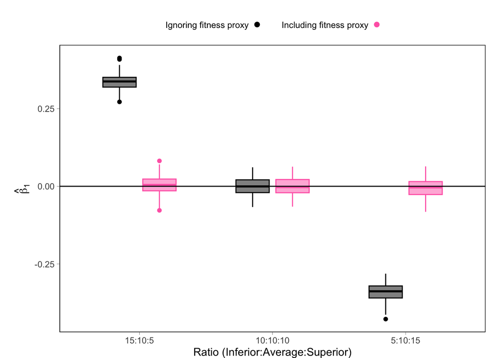

```r
plot.2.b <- plot.sim.boxplot(sim.res.sc2, "0 -1")
plot.2.b
```

```r
legend.plot.rel <- as_ggplot(get_legend(plot.2.a))
```

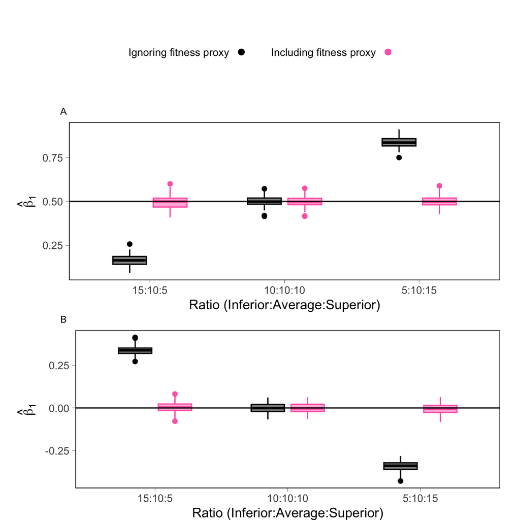

```r
ggarrange(legend.plot.rel,
  ggarrange(plot.2.a, plot.2.b,  legend = "none",
          labels = c("A", "B"), label.x = rep(0.11,4), label.y = rep(1, 4),
              font.label = list(size = 8, face="plain"),
          nrow = 2, ncol = 1), nrow=2, ncol=1, heights = c(0.2,0.8))
```

## Scenario 3: check what to do when only one used location per individual

Here we are going to increase the number of individuals, as we only have one used point per individuals

```r
# Number of individuals
n <- 50
# Number of points per individual
n.points <- 1
# Number of simulation per scenario
n.sim <- 100
# Number of available per points
n.avail <- 100
```

It’s just to assess that we can recover parameters, so no need to go into a range of ratios. We will use two imbalance ratios to make sure that it’s robust to imbalance. Looking at whether we need the random effect on the intercept. By definition, it can’t be on the other coefficients as there are not enough points to capture variability, but we are verifying here that the intercept is needed to capture the link with available points.

```r
betas.sc3 <- matrix(c(0.5, 1), nrow = 1, byrow = TRUE)

# This work with n = 50
proxy.sc3 <- matrix(c(10, 15, 25,
                      25, 15, 10),
                    byrow = TRUE, nrow = 2)
colnames(proxy.sc3) <- c("n_m1", "n_0", "n_p1")

sim.res.sc3 <- as.data.frame(matrix(nrow = n.sim*nrow(proxy.sc3)*nrow(betas.sc3),
                                    ncol = 27))
colnames(sim.res.sc3) <- c("sim", "n_m1", "n_0", "n_p1", "cov.sim.index",
                           "beta_cov_est_re", "beta_cov_SE_re",
                           "beta_cov_95LCI_re", "beta_cov_95UCI_re",
                           "beta_cov_in_95CI_re",
                           "beta_cov_proxy_est_re", "beta_cov_proxy_SE_re",
                           "beta_cov_proxy_95LCI_re", "beta_cov_proxy_95UCI_re",
                           "beta_cov_proxy_in_95CI_re",
                           "beta_cov_est_no_re", "beta_cov_SE_no_re",
                           "beta_cov_95LCI_no_re", "beta_cov_95UCI_no_re",
                           "beta_cov_in_95CI_no_re",
                           "beta_cov_proxy_est_no_re", "beta_cov_proxy_SE_no_re",
                           "beta_cov_proxy_95LCI_new", "beta_cov_proxy_95UCI_new",
                           "beta_cov_proxy_in_95CI_new",
                           "converg_mess_re", "converg_mess_no_re")

sim.res.sc3[,"sim"] <- 1:(n.sim*nrow(betas.sc3)*nrow(proxy.sc3))

sim.res.sc3[,"cov.sim.index"] <- rep(1:n.sim, nrow(betas.sc3)*nrow(proxy.sc3))

sim.res.sc3[, "n_m1"] <- rep(proxy.sc3[,"n_m1"], each = n.sim*nrow(betas.sc3))
sim.res.sc3[, "n_0"] <- rep(proxy.sc3[,"n_0"], each = n.sim*nrow(betas.sc3))
sim.res.sc3[, "n_p1"] <- rep(proxy.sc3[,"n_p1"], each = n.sim*nrow(betas.sc3))

sim.res.sc3[, "beta_cov_sim"] <- rep(betas.sc3[,1], each = n.sim)
sim.res.sc3[, "beta_cov_proxy_sim"] <- rep(betas.sc3[,2], each = n.sim)

sim.res.sc3$beta_sim_factor <- paste(sim.res.sc3$beta_cov_sim, sim.res.sc3$beta_cov_proxy_sim)
sim.res.sc3$proxy_factor <- factor(paste("-1: ", sim.res.sc3$n_m1,
                                         ", 0: ", sim.res.sc3$n_0,
                                         ", +1: ", sim.res.sc3$n_p1, sep = ""))
```

**This will take mins to hours to run on most computers.** We provided a .csv file with the results in the repository that can be loaded below.

```r
t0 <- Sys.time()
# Use same set of covariates for each scenarios
set.seed(123454321)
cov.sc3 <- simulate_data(study.area, n = 1, scale = 0.9, sd = 0.1)
for(i in 2:n.sim){
  cov.sc3 <- rast(list(cov.sc3,
                       simulate_data(study.area, n = 1, scale = 0.9, sd = 0.1)))
}

set.seed(666555444)
for(s in 1:nrow(sim.res.sc3)){

  sim.s <- sim.rsf(n, n.points,
                   proxy = c(rep(-1, sim.res.sc3[s, "n_m1"]),
                             rep(0, sim.res.sc3[s, "n_0"]),
                             rep(+1, sim.res.sc3[s, "n_p1"])),
                   cov.sc3[[sim.res.sc3[s,"cov.sim.index"]]],
                   betas = as.numeric(sim.res.sc3[s,
                                                  c("beta_cov_sim",
                                                    "beta_cov_proxy_sim")]))

  all.s <- avail.rsf(n.avail, study.area.sf, used.sf = sim.s,
                     cov = cov.sc3[[sim.res.sc3[s,"cov.sim.index"]]])

  # with re on intercept
  fit.s.re <- fit.rsf(all.s,
                         formula.rsf = case ~ cov + cov:proxy + (1 | ID),
                          start = list(theta = log(10000)),
                      map = list(theta = factor(NA)))
  sim.res.sc3[s, c("beta_cov_est_re", "beta_cov_SE_re")] <-
    summary(fit.s.re)$coefficient$cond["cov", c("Estimate", "Std. Error")]
  sim.res.sc3[s, c("beta_cov_95LCI_re", "beta_cov_95UCI_re")] <-
    confint(fit.s.re, "cov")[,1:2]
  sim.res.sc3[s, c("beta_cov_proxy_est_re", "beta_cov_proxy_SE_re")] <-
    summary(fit.s.re)$coefficient$cond["cov:proxy", c("Estimate", "Std. Error")]
  sim.res.sc3[s, c("beta_cov_proxy_95LCI_re", "beta_cov_proxy_95UCI_re")] <-
    confint(fit.s.re, "cov:proxy")[,1:2]
  sim.res.sc3[s, "converg_mess_re"] <-
    fit.s.re$fit$convergence

  # with without on intercept
  fit.s.no.re <- fit.rsf(all.s,
                         formula.rsf = case ~ cov + cov:proxy,
                          start = NULL, map = NULL)
  sim.res.sc3[s, c("beta_cov_est_no_re", "beta_cov_SE_no_re")] <-
    summary(fit.s.no.re)$coefficient$cond["cov", c("Estimate", "Std. Error")]
  sim.res.sc3[s, c("beta_cov_95LCI_no_re", "beta_cov_95UCI_no_re")] <-
    confint(fit.s.no.re, "cov")[,1:2]
  sim.res.sc3[s, c("beta_cov_proxy_est_no_re", "beta_cov_proxy_SE_no_re")] <-
    summary(fit.s.no.re)$coefficient$cond["cov:proxy", c("Estimate", "Std. Error")]
  sim.res.sc3[s, c("beta_cov_proxy_95LCI_no_re", "beta_cov_proxy_95UCI_no_re")] <-
    confint(fit.s.no.re, "cov:proxy")[,1:2]
  sim.res.sc3[s, "converg_mess_no_re"] <-
    fit.s.no.re$fit$convergence
}
Sys.time() - t0
```

```
## Time difference of 7.010186 mins
```

```r
# Save file
write.csv(sim.res.sc3,
          file = paste("sim.rsf.sc3_", format(Sys.time(), "%Y%m%d"), ".csv",
                               sep=""),
          row.names = FALSE)
```

To load the results saved, uncomment the line in this code chunk.

```r
# sim.res.sc3 <- read.csv("sim.rsf.sc2_20251112.csv")
```

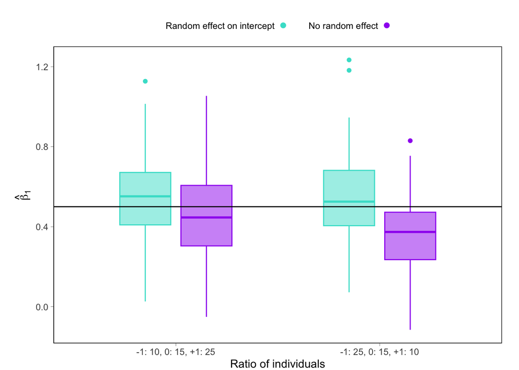

```r
col.re.method <- "turquoise"
col.no.re.method <- "purple"

# Cov coef

ggplot() +
  geom_boxplot(data = sim.res.sc3, aes(x= proxy_factor, y= beta_cov_est_re),
                 width = 0.25, position= position_nudge(x=-.15),
                 col = col.re.method, fill = alpha(col.re.method, 0.5)) +
    geom_boxplot(data = sim.res.sc3, aes(x= proxy_factor, y= beta_cov_est_no_re),
                 width = 0.25, position= position_nudge(x=+.15),
                 col = col.no.re.method, fill = alpha(col.no.re.method, 0.5)) +
    geom_hline(aes(yintercept =unique(sim.res.sc3$beta_cov_sim))) +
    xlab("Ratio of individuals") + ylab(expression(hat(beta)[1])) +
    theme(panel.border = element_rect(fill=NA, linewidth = 0.5)) +
    guides(RE = guide_custom(grid::circleGrob(r = unit(0.1, "cm"),
                                                  gp = grid::gpar(fill = col.re.method,
                                                                  col = NA)),
                                 title = "Random effect on intercept", order = 1,
                                 theme = theme(legend.title =
                                                 element_text(size = axis.label.size),
                                               legend.position = "top")),
           NO.RE = guide_custom(grid::circleGrob(r = unit(0.1, "cm"),
                                                  gp = grid::gpar(fill = col.no.re.method,
                                                                  col = NA)),
                                 title = "No random effect", order = 2,
                                 theme = theme(legend.title =
                                                 element_text(size = axis.label.size),
                                               legend.position = "top"))) +
  theme_classic() +
  theme(legend.position = "top",
          axis.title = element_text(size = axis.title.size),
          axis.text = element_text(size = axis.label.size),
          panel.border = element_rect(colour = "black", fill=NA, linewidth = 0.5),
          axis.line = element_line(colour = 'black', linewidth = 0.1),
          axis.ticks = element_line(colour = 'black', linewidth = 0.1),
          plot.margin = unit(c(1.05, 1.15, 0, 1), 'lines'))
```

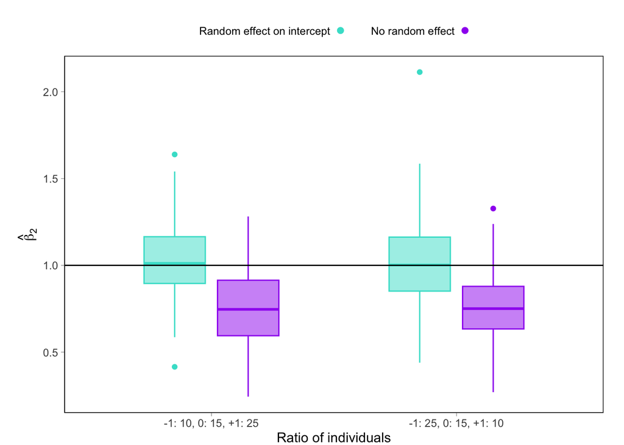

```r
# cov:proxy

ggplot() +
  geom_boxplot(data = sim.res.sc3, aes(x= proxy_factor, y= beta_cov_proxy_est_re),
                 width = 0.25, position= position_nudge(x=-.15),
                 col = col.re.method, fill = alpha(col.re.method, 0.5)) +
    geom_boxplot(data = sim.res.sc3, aes(x= proxy_factor, y= beta_cov_proxy_est_no_re),
                 width = 0.25, position= position_nudge(x=+.15),
                 col = col.no.re.method, fill = alpha(col.no.re.method, 0.5)) +
    geom_hline(aes(yintercept =unique(sim.res.sc3$beta_cov_proxy_sim))) +
    xlab("Ratio of individuals") + ylab(expression(hat(beta)[2])) +
    theme(panel.border = element_rect(fill=NA, linewidth = 0.5)) +
    guides(RE = guide_custom(grid::circleGrob(r = unit(0.1, "cm"),
                                                  gp = grid::gpar(fill = col.re.method,
                                                                  col = NA)),
                                 title = "Random effect on intercept", order = 1,
                                 theme = theme(legend.title =
                                                 element_text(size = axis.label.size),
                                               legend.position = "top")),
           NO.RE = guide_custom(grid::circleGrob(r = unit(0.1, "cm"),
                                                  gp = grid::gpar(fill = col.no.re.method,
                                                                  col = NA)),
                                 title = "No random effect", order = 2,
                                 theme = theme(legend.title =
                                                 element_text(size = axis.label.size),
                                               legend.position = "top"))) +
  theme_classic() +
  theme(legend.position = "top",
          axis.title = element_text(size = axis.title.size),
          axis.text = element_text(size = axis.label.size),
          panel.border = element_rect(colour = "black", fill=NA, linewidth = 0.5),
          axis.line = element_line(colour = 'black', linewidth = 0.1),
          axis.ticks = element_line(colour = 'black', linewidth = 0.1),
          plot.margin = unit(c(1.05, 1.15, 0, 1), 'lines'))
```

As I expected, we need the random effect on the intercept. If the random effect is not included, the estimates are biased. I note that the estimates of $\beta_1$ are not perfect even when the random effect is included, but it is beyond the scope of the paper to look at this in detail.

# Literature cited

Muff S., Signer J., & Fieberg J. (2020). Accounting for individual-specific variation in habitat-selection studies: Efficient estimation of mixed-effects models using Bayesian or frequentist computation. J Anim Ecol, 89, 80–92. https://doi.org/10.1111/1365-2656.13087